# Analysis of Pont-to-point experiments of MPI calls

```r
opts_chunk$set(cache=FALSE,dpi=300,echo=FALSE)
```

If needed, you should install the right packages (plyr, ggplot2, and knitr) with the install.packages command.

Load XML config file and .csv resulting files from the MPI execution

## MPI_Send timing

Timings for this experiment are taken from a ping-pong experiment, used to determine os.

We determine the piecewiese regression based on information taken from the regression file pointed in the XML configuration file

```
##        Limit     Name LimitInf
## 1        150    Small        0
## 2       8192   Medium      150
## 3     260000 Detached     8192
## 4 2147483647    Large   260000
```

Display the regression factors to help tuning.

```
## [1] "----- Small-----"
##
## Call:
## lm(formula = Duration ~ Size, data = d[d$group == bp[bp$Limit ==
##     lim, ]$Name, ])
##
## Residuals:
##        Min         1Q     Median         3Q        Max
## -5.891e-08 -1.610e-08 -5.531e-09  1.000e-08  1.693e-07
##
## Coefficients:
##              Estimate Std. Error t value Pr(>|t|)
## (Intercept) 2.138e-07  3.473e-10  615.50   <2e-16 ***
## Size        1.067e-10  7.546e-12   14.14   <2e-16 ***
## ---
## Signif. codes:  0 '***' 0.001 '**' 0.01 '*' 0.05 '.' 0.1 ' ' 1
##
## Residual standard error: 2.645e-08 on 9907 degrees of freedom
## Multiple R-squared:  0.01978,    Adjusted R-squared:  0.01968
## F-statistic: 199.9 on 1 and 9907 DF,  p-value: < 2.2e-16
##
## [1] "----- Medium-----"
##
## Call:
## lm(formula = Duration ~ Size, data = d[d$group == bp[bp$Limit ==
##     lim, ]$Name, ])
##
## Residuals:
##        Min         1Q     Median         3Q        Max
## -1.745e-07 -4.368e-08 -7.750e-09  2.004e-08  1.578e-06
##
## Coefficients:
##              Estimate Std. Error t value Pr(>|t|)
## (Intercept) 2.429e-07  1.874e-09   129.7   <2e-16 ***
## Size        7.650e-11  6.290e-13   121.6   <2e-16 ***
## ---
## Signif. codes:  0 '***' 0.001 '**' 0.01 '*' 0.05 '.' 0.1 ' ' 1
##
## Residual standard error: 1.205e-07 on 7718 degrees of freedom
## Multiple R-squared:  0.6572, Adjusted R-squared:  0.6571
## F-statistic: 1.479e+04 on 1 and 7718 DF,  p-value: < 2.2e-16
```

Visual representation of the computed data, to visualize correctness of the computed value.

The black line representing the regression should be very close to the values, and should drop to 0 when communications use the rendez-vous algorithm (Large messages, with a size > eager_threshold).

If they are not, tune the breakpoints in order to match more closely to your implementation. Thresholds for eager and detached messages depend on the library and the hardware used. Consult the documentation of your library on how to display this information if you can't visually determine it (For Ethernet network we saw values of 65536, while IB networks had values of 12288 or 17408 depending on the implementation)

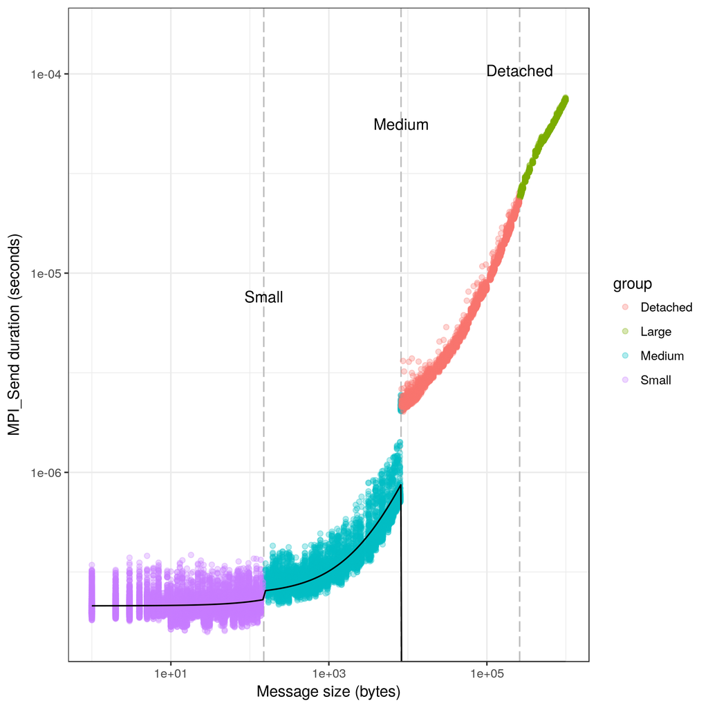

## MPI_Isend timing

As they may differ from Send times, check this and call it ois, to inject proper timings later.

Display the regression factors to help tuning

```
## [1] "----- Small-----"
##
## Call:
## lm(formula = Duration ~ Size, data = d[d$group == bp[bp$Limit ==
##     lim, ]$Name, ])
##
## Residuals:
##        Min         1Q     Median         3Q        Max
## -3.954e-08 -1.264e-08 -4.531e-09  7.572e-09  2.537e-07
##
## Coefficients:
##              Estimate Std. Error t value Pr(>|t|)
## (Intercept) 2.202e-07  2.473e-10  890.52   <2e-16 ***
## Size        8.046e-11  5.373e-12   14.97   <2e-16 ***
## ---
## Signif. codes:  0 '***' 0.001 '**' 0.01 '*' 0.05 '.' 0.1 ' ' 1
##
## Residual standard error: 1.887e-08 on 9959 degrees of freedom
## Multiple R-squared:  0.02202,    Adjusted R-squared:  0.02192
## F-statistic: 224.3 on 1 and 9959 DF,  p-value: < 2.2e-16
##
## [1] "----- Medium-----"
##
## Call:
## lm(formula = Duration ~ Size, data = d[d$group == bp[bp$Limit ==
##     lim, ]$Name, ])
##
## Residuals:
##        Min         1Q     Median         3Q        Max
## -4.458e-07 -3.242e-08 -1.024e-08  1.142e-08  6.751e-07
##
## Coefficients:
##              Estimate Std. Error t value Pr(>|t|)
## (Intercept) 2.597e-07  1.232e-09   210.8   <2e-16 ***
## Size        6.505e-11  4.135e-13   157.3   <2e-16 ***
## ---
## Signif. codes:  0 '***' 0.001 '**' 0.01 '*' 0.05 '.' 0.1 ' ' 1
##
## Residual standard error: 7.934e-08 on 7730 degrees of freedom
## Multiple R-squared:  0.762,  Adjusted R-squared:  0.7619
## F-statistic: 2.475e+04 on 1 and 7730 DF,  p-value: < 2.2e-16
```

Visual representation of the computed data, to visualize correctness of the computed value

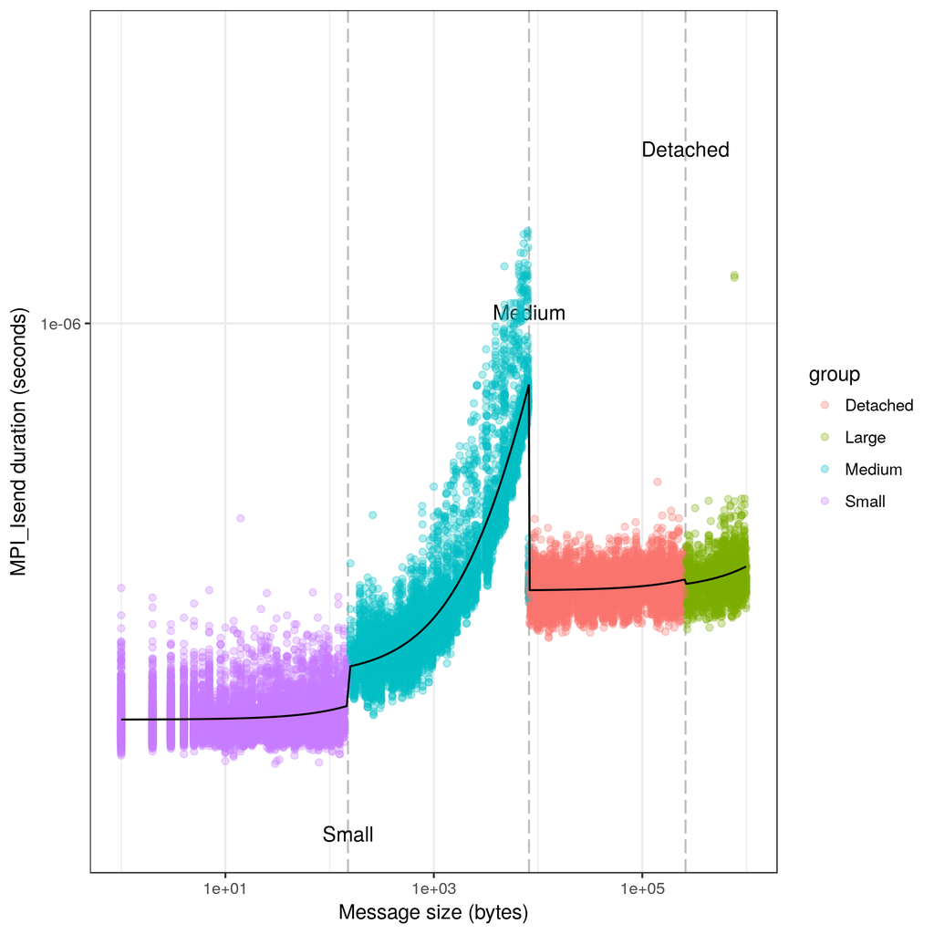

## MPI_Recv timing

Timings are used to determine or. This experiment waits for a potentially eager message to arrive before launching the recv for small message size, eliminating waiting times as much as possible.

Display the regression factors to help tuning

```
## [1] "----- Small-----"
##
## Call:
## lm(formula = Duration ~ Size, data = d[d$group == bp[bp$Limit ==
##     lim, ]$Name, ])
##
## Residuals:
##        Min         1Q     Median         3Q        Max
## -5.861e-08 -1.662e-08 -6.180e-09  6.350e-09  4.151e-07
##
## Coefficients:
##              Estimate Std. Error t value Pr(>|t|)
## (Intercept) 7.571e-07  4.960e-10 1526.40   <2e-16 ***
## Size        3.057e-10  1.078e-11   28.36   <2e-16 ***
## ---
## Signif. codes:  0 '***' 0.001 '**' 0.01 '*' 0.05 '.' 0.1 ' ' 1
##
## Residual standard error: 3.773e-08 on 9883 degrees of freedom
## Multiple R-squared:  0.07524,    Adjusted R-squared:  0.07515
## F-statistic: 804.1 on 1 and 9883 DF,  p-value: < 2.2e-16
##
## [1] "----- Medium-----"
##
## Call:
## lm(formula = Duration ~ Size, data = d[d$group == bp[bp$Limit ==
##     lim, ]$Name, ])
##
## Residuals:
##        Min         1Q     Median         3Q        Max
## -1.439e-07 -3.742e-08 -1.710e-08  4.630e-09  1.350e-06
##
## Coefficients:
##              Estimate Std. Error t value Pr(>|t|)
## (Intercept) 8.090e-07  1.744e-09   463.9   <2e-16 ***
## Size        1.234e-10  5.858e-13   210.6   <2e-16 ***
## ---
## Signif. codes:  0 '***' 0.001 '**' 0.01 '*' 0.05 '.' 0.1 ' ' 1
##
## Residual standard error: 1.121e-07 on 7713 degrees of freedom
## Multiple R-squared:  0.8519, Adjusted R-squared:  0.8519
## F-statistic: 4.436e+04 on 1 and 7713 DF,  p-value: < 2.2e-16
```

Visual representation of the computed data, to visualize correctness of the computed value

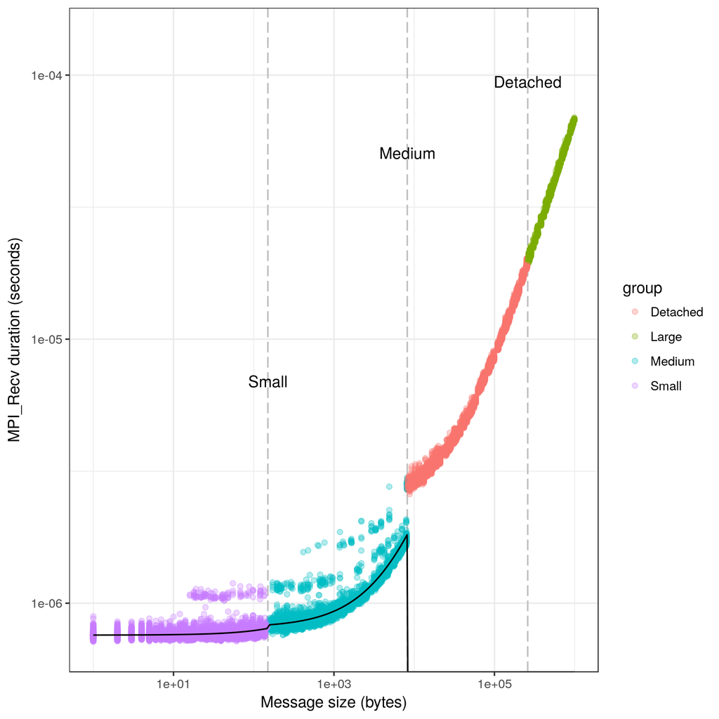

## Pingpong timing

pingpong = 2or+2transfer for small messages that are sent asynchronously. For large sizes, communications are synchronous, hence we have pingpong = 2transfer.

```
## [1] "----- Small-----"
##
## Call:
## lm(formula = Duration ~ Size, data = d[d$group == bp[bp$Limit ==
##     lim, ]$Name, ])
##
## Residuals:
##        Min         1Q     Median         3Q        Max
## -2.220e-07 -7.310e-08 -3.437e-08  1.702e-08  3.095e-06
##
## Coefficients:
##              Estimate Std. Error t value Pr(>|t|)
## (Intercept) 5.893e-07  2.039e-09  289.06   <2e-16 ***
## Size        9.245e-10  4.425e-11   20.89   <2e-16 ***
## ---
## Signif. codes:  0 '***' 0.001 '**' 0.01 '*' 0.05 '.' 0.1 ' ' 1
##
## Residual standard error: 1.726e-07 on 12248 degrees of freedom
## Multiple R-squared:  0.03441,    Adjusted R-squared:  0.03433
## F-statistic: 436.5 on 1 and 12248 DF,  p-value: < 2.2e-16
##
## [1] "----- Medium-----"
##
## Call:
## lm(formula = Duration ~ Size, data = d[d$group == bp[bp$Limit ==
##     lim, ]$Name, ])
##
## Residuals:
##        Min         1Q     Median         3Q        Max
## -4.657e-07 -1.178e-07 -4.610e-08  4.620e-08  7.141e-06
##
## Coefficients:
##              Estimate Std. Error t value Pr(>|t|)
## (Intercept) 7.315e-07  3.870e-09   189.0   <2e-16 ***
## Size        3.566e-10  1.298e-12   274.7   <2e-16 ***
## ---
## Signif. codes:  0 '***' 0.001 '**' 0.01 '*' 0.05 '.' 0.1 ' ' 1
##
## Residual standard error: 2.775e-07 on 9598 degrees of freedom
## Multiple R-squared:  0.8872, Adjusted R-squared:  0.8872
```

[output cut: 28 more lines]

```
##
## Residuals:
##        Min         1Q     Median         3Q        Max
## -5.075e-06 -1.611e-06 -1.148e-07  1.460e-06  2.963e-05
##
## Coefficients:
##              Estimate Std. Error t value Pr(>|t|)
## (Intercept) 1.203e-05  1.273e-07    94.5   <2e-16 ***
## Size        1.330e-10  2.036e-13   653.4   <2e-16 ***
## ---
## Signif. codes:  0 '***' 0.001 '**' 0.01 '*' 0.05 '.' 0.1 ' ' 1
##
## Residual standard error: 2.266e-06 on 2798 degrees of freedom
## Multiple R-squared:  0.9935, Adjusted R-squared:  0.9935
## F-statistic: 4.269e+05 on 1 and 2798 DF,  p-value: < 2.2e-16
```

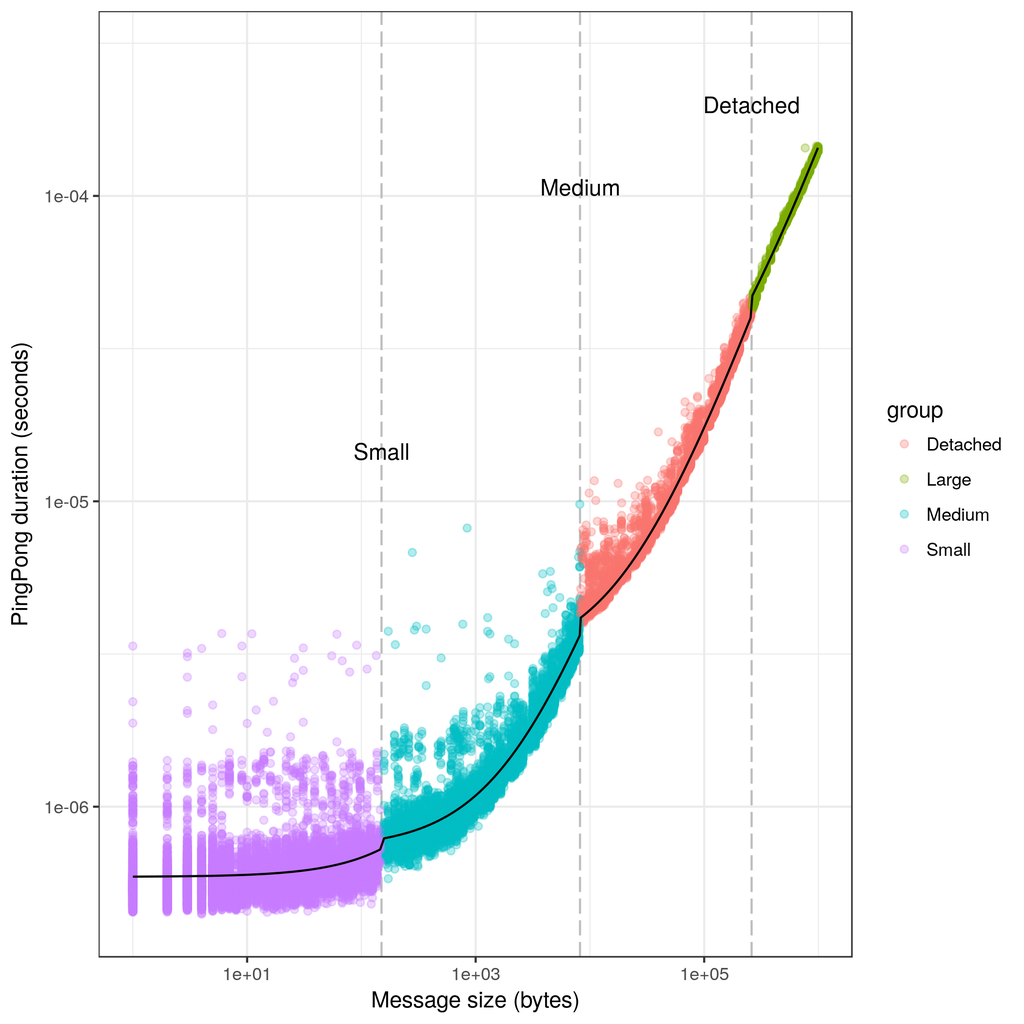

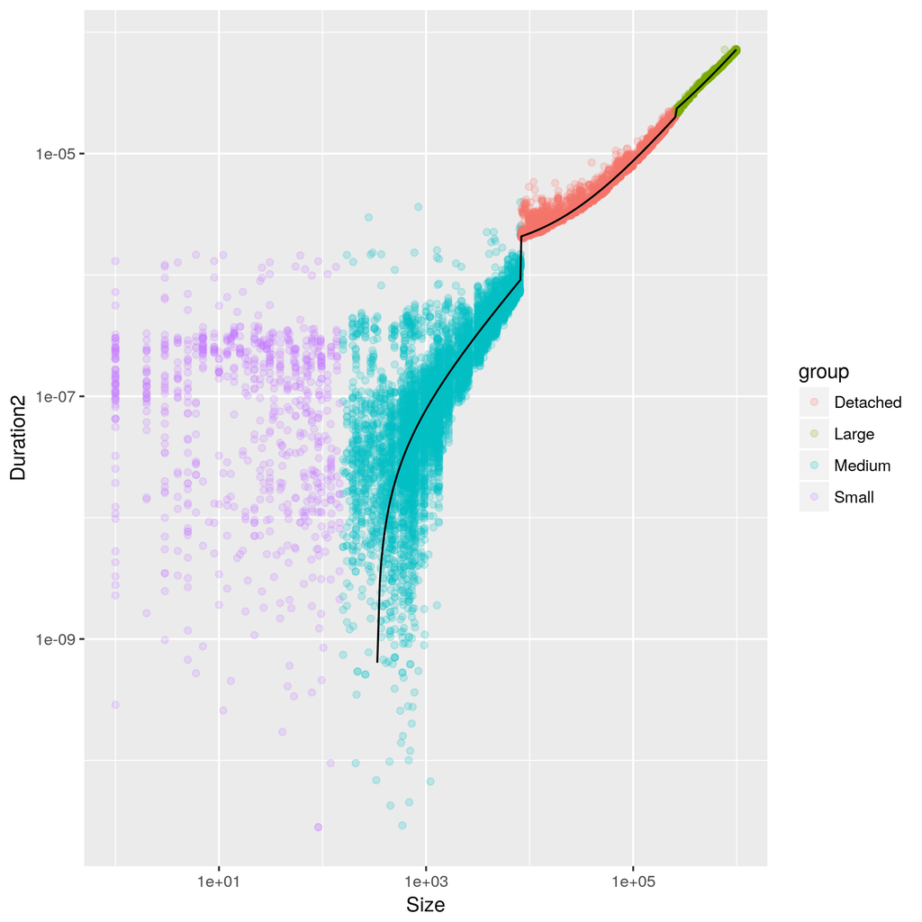

Print results in Simgrid's xml format

## MPI_Wtime timing

We made a run with 10 millions calls to MPI_Wtime and we want to know the time of one call

Time for one MPI_Wtime call

```
## [1] 3.854044e-08
```

## MPI_Iprobe timing

We made 1000 runs of pingpong with pollling on MPI_Iprobe. Compute the Duration of such a call, and check whether its time is related to the size of the message

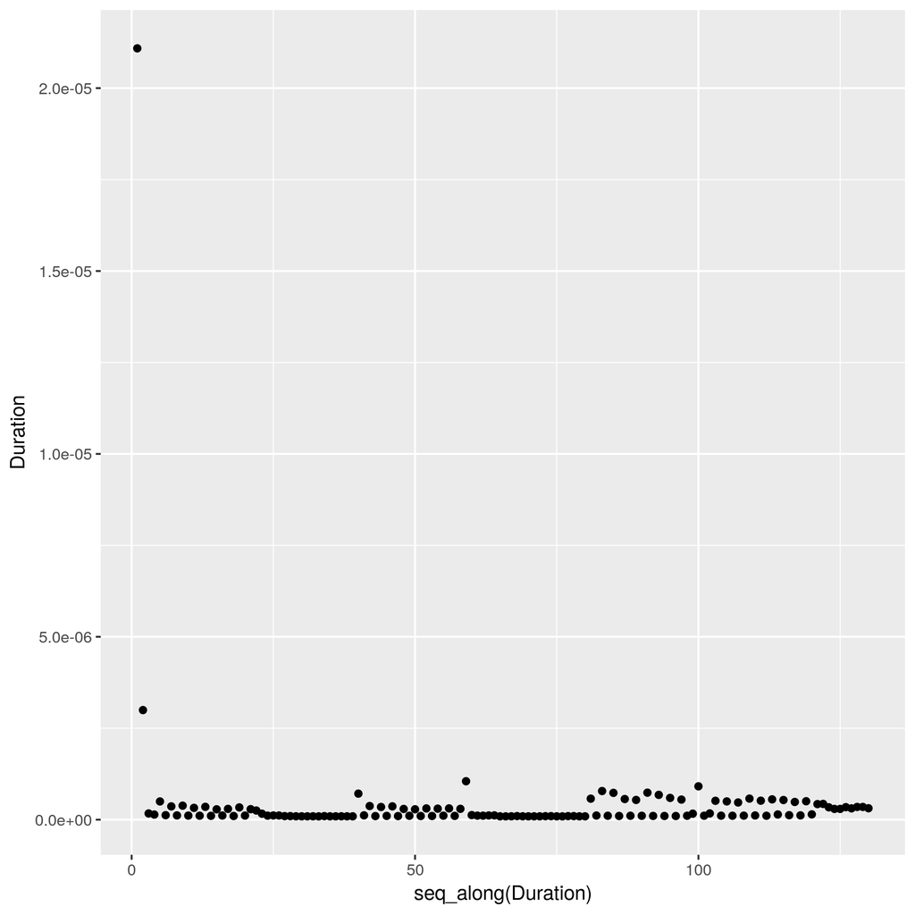

Time for one MPI_Iprobe call

```
## [1] 2.118654e-07
```

## MPI_Test timing

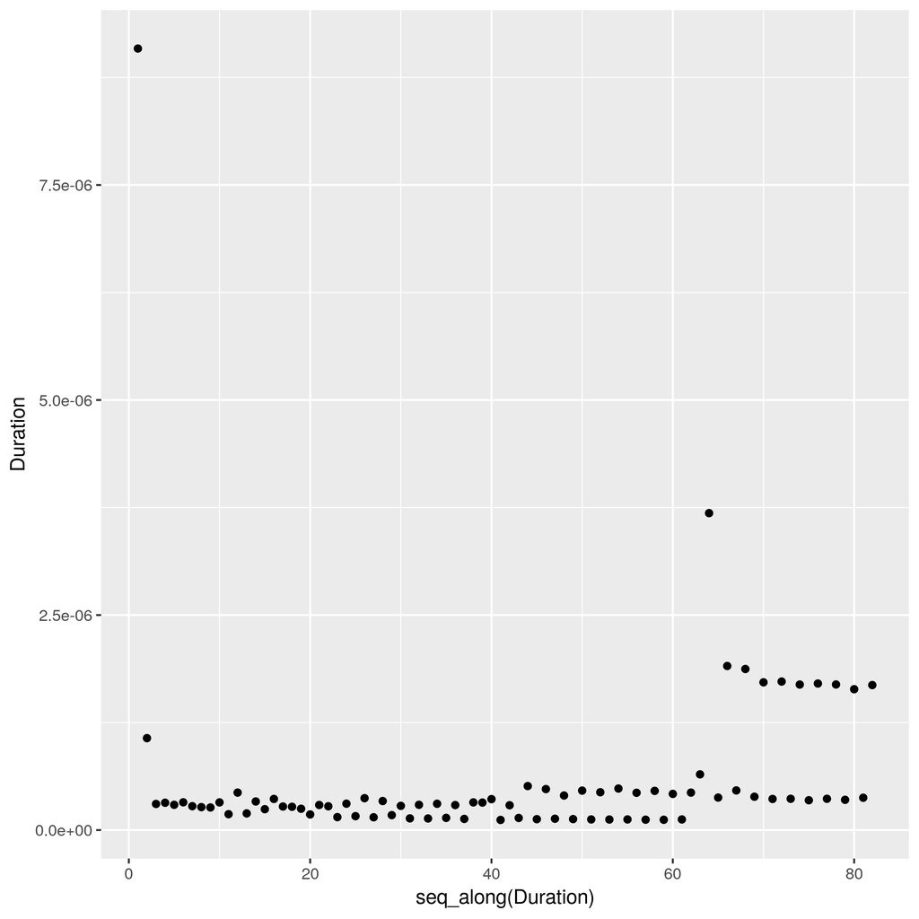

Time for one MPI_Test call

```
## [1] 3.844091e-07
```

## Result of calibration.

The following snippet of XML has to be included at the beginning of your platformfile. Please report to the SimGrid mailing list any bug with the calibration or the generated platform file.

```
## <config id="General">
##  <prop id="smpi/os" value="0:2.13783708646423e-07:1.06707127905172e-10;150:2.42931856945795e-07:7.6498173343884e-11;8192:0:0;260000:0:0"/>
##  <prop id="smpi/ois" value="0:2.20186567283027e-07:8.04567539633742e-11;150:2.59694059503062e-07:6.50488293734537e-11;8192:3.60521549711139e-07:6.08822065955243e-14;260000:3.60598825380314e-07:3.49007350294146e-14"/>
##  <prop id="smpi/or" value="0:7.57121059121353e-07:3.05743835683745e-10;150:8.09023385156419e-07:1.23381322615915e-10;8192:0:0;260000:0:0"/>
##  <prop id="smpi/bw-factor" value="0:1;150:1;8192:1;260000:1"/>
##  <prop id="smpi/lat-factor" value="0:1;150:1;8192:1;260000:1"/>
##  <prop id="smpi/async-small-thres" value="17408"/>
##  <prop id="smpi/send-is-detached-thres" value="17408"/>
##  <prop id="smpi/wtime" value="3.854044e-08"/>
##  <prop id="smpi/iprobe" value="2.11865384615385e-07"/>
##  <prop id="smpi/test" value="3.84409090909091e-07"/>
## </config>
```

```
## [1] "Results written in testplatform.xml"
```

```
## [1] "testplatform_output.xml"
```